# TrIdent Tutorial

Jessie Maier

2023-12-31

### Description:

TrIdent is a reference-independent bioinformatics tool that automates the analysis of transductomics data by automatically detecting, classifying and characterizing potential transducing events. Transductomics is a DNA-sequencing based method for the detection and characterization of transduction events. Developed by Kleiner et al. (2020), transductomics relies on mapping reads from a virome (VLP-fraction) of a sample to contigs assembled from the metagenome (whole-community) of the same sample. Reads from bacterial DNA carried by viruses and other VLPs (Virus-like particles) will map back to the bacterial contigs of origin creating read coverage patterns indicative of potential ongoing transduction.

**Reference:** Kleiner, M., Bushnell, B., Sanderson, K.E. et al. Transductomics: sequencing-based detection and analysis of transduced DNA in pure cultures and microbial communities. Microbiome 8, 158 (2020). https://doi.org/10.1186/s40168-020-00935-5

# TrIdent tutorial:

### **TrIdent**- **Tr**ansduction **Ident**ification

TrIdent consists of three main functions to automatically detect, classify, and characterize potential transducing events:

- `TrIdent_Classifier()`: Classifies contigs as ‘Prophage-like’, ‘Sloping’, ‘HighCoverageNoPattern’, and ‘InsufficientCoverage’
- `PlotTrIdentPatternMatches()`: Plots results of TrIdent_Classifier
- `SpecializedTransduction_ID()`: Detects potential specialized transduction on contigs classified as Prophage-like

Running TrIdent in default mode is the easiest, but users can learn how to use various arguments to modify TrIdent’s results in this tutorial.

#### Input Data:

The datasets used in this tutorial- ‘VLPFraction_sampledata’ and ‘WholeCommunity_sampledata’- were generated from a conventional mouse fecal metagenome. The homogenized feces represents the whole-community. The VLP-fraction of the fecal sample was separated and purified via CsCl density gradient ultracentrifugation. Both the whole-community and VLP-fraction were sequenced with Illumina (paired-end mode, 150 bp reads) after which the metagenome was assembled from the whole-community reads. The whole-community and VLP-fraction raw reads were mapped to the metagenome contigs using [BBMap](https://jgi.doe.gov/data-and-tools/software-tools/bbtools/bb-tools-user-guide/bbmap-guide/). The BBMap command generates two pileup files to summarize the respective read coverages across each contig. The contigs were filtered prior to mapping to remove contigs less than 30 kbp. **Note- Specific sequencing requirements are needed for transductomics! Sample preparation and sequencing procedures are detailed in Kleiner et al. (2020).** A subset of 10 contigs from the mouse fecal metagenome were selected for the sample dataset used in this tutorial.

**Use the commands below (with your own files) to generate the pileup files needed for TrIdent. Note that the covbinsize/windowsize must be 100!**

```bash
 bbmap.sh ambiguous=random minid=0.97 reference=WC_filteredcontigs.fa in1=VLPreads_R1.fa in2=VLPreads_R2.fa bincov=VLP_pileup covbinsize=100

bbmap.sh ambiguous=random minid=0.97 reference=WC_filteredcontigs.fa in1=WCreads_R1.fa in2=WCreads_R2.fa bincov=WC_pileup covbinsize=100
```

#### In R…

Load the package into your library. If you don’t already have TrIdent, you can find installation instructions here

```r
library(TrIdent)
```

Import your pileup files:

Note The ‘VLPFraction_sampledata’ and ‘WholeCommunity_sampledata’ pileup files needed for the tutorial come preloaded with the TrIdent package. There is no nead to load or import these files.

Here is what the raw pileup file should look like: (note that the information in the first column may be formatted differently depending on your contig accession format)

```
##                                           V1   V2  V3      V4
##  NODE_4 length_493049_cov_5.62057_ID_9556231 2.62 100 1938832
##  NODE_4 length_493049_cov_5.62057_ID_9556231 6.94 200 1938932
##  NODE_4 length_493049_cov_5.62057_ID_9556231 6.39 300 1939032
##  NODE_4 length_493049_cov_5.62057_ID_9556231 5.98 400 1939132
##  NODE_4 length_493049_cov_5.62057_ID_9556231 8.12 500 1939232
##  NODE_4 length_493049_cov_5.62057_ID_9556231 5.02 600 1939332
```

- The first column contains character strings of the contig accessions given by the assembler used.
- The second column contains numerical values of read coverages binned over 100 bp regions.
- The third column contains integer values for the starting position of each 100 bp bin. The position restarts at the start of each new contig.
- The fourth column contains integer values for the starting position of each 100 bp bin. The position does NOT restart at the start of each new contig.

The ‘VLPFraction_bincov100.txt’ and ‘WholeCommunity_bincov100.txt’ files generated by BBMap’s `pileup.sh` in the example above could be used directly as input to TrIdent. TrIdent has built-in data cleaning and reformatting for files output specifically by BBMap’s `pileup.sh`. If you do not use BBMap’s `pileup.sh` to generate the pileup files, then you are responsible for data-cleaning and reformatting. Your pileup files must be in the following format (same column names, same column classes, etc.) and you must use the `cleanup=FALSE` argument for the `TrIdent_classifier()`, `Plot_TrIdentPatternMatches()`, and `SpecializedTransduction_ID()`.

```
##  ref_name coverage position
##    NODE_4     2.62      100
##    NODE_4     6.94      200
##    NODE_4     6.39      300
##    NODE_4     5.98      400
##    NODE_4     8.12      500
##    NODE_4     5.02      600
```

The `CleanVLPFraction_sampledata` comes preloaded with TrIdent and provides an example of a cleaned and reformatted pileup file. Please use this dataframe as an example if you are doing your own data-cleaning and reformatting.

## Running TrIdent:

### `TrIdent_Classifier()`:

`TrIdent_Classifier()` is the main function that TrIdent relies on. This function cleans and reformats your input data, filters contigs based on length and read coverage, performs pattern-matching to classify contigs, identifies active/highly abundant and heterogenously integrated prophage-like elements, determines which contigs have high VLP-fraction:whole-community read coverage ratios, identifies start and stop positions and sizes of pattern matches, calculates slopes for Sloping pattern matches, generates a pattern-match quality score and outputs all information in a neat summary table.

`TrIdent_Classifier()` features:

**1. Contig filtering:**

Contigs are filtered out based on short length or low read coverage. TrIdent filters out contigs that do not have at least 10x coverage on a total of 5000 bp across the whole contig due to insufficient read coverage. Contigs where the 50th greatest coverage value is less than 10 means that there is no region on the contig with read coverages greater than 10 for at least 5,000bp. The low read coverage filtering was done in this way to avoid filtering out long contigs with short Prophage-like patterns that might get removed if filtering was done with averages or medians. Additionally, contigs less than 30 kbp are filtered out by default, however this can be changed with the `MinContigLength` parameter. Contigs shorter than 30 kbp may be poor quality and are not big enough to show clear transduction patterns. **If you would like to speed-up processing time of TrIdent, consider pre-filtering your assembly for contigs greater than 30 kbp!**

**2. Pattern-matching:**

Contigs that are not filtered out proceed to pattern-matching where they are matched with a variety of patterns representing transduction events. Patterns are ‘built’ and the x and y-axis values are scaled specific to the characteristics of each contig to ensure the pattern-matching is data agnostic. After a pattern is built, it is translated across the contig being assessed, and the mean absolute difference in coverage (match-score) between the contig and the pattern is calculated at each translation. Theoretically, **if a pattern is a perfect match to the coverages on a contig, then taking the mean absolute difference in y-axis values will result in a 0. Obviously, no pattern will be a perfect match to a contig, but the closer to 0 the match-score is, the better that pattern matches the read coverage pattern on the contig.** The contig is classified based on the pattern that achieves the lowest match-score.

##### Patterns:

- **Sloping:**

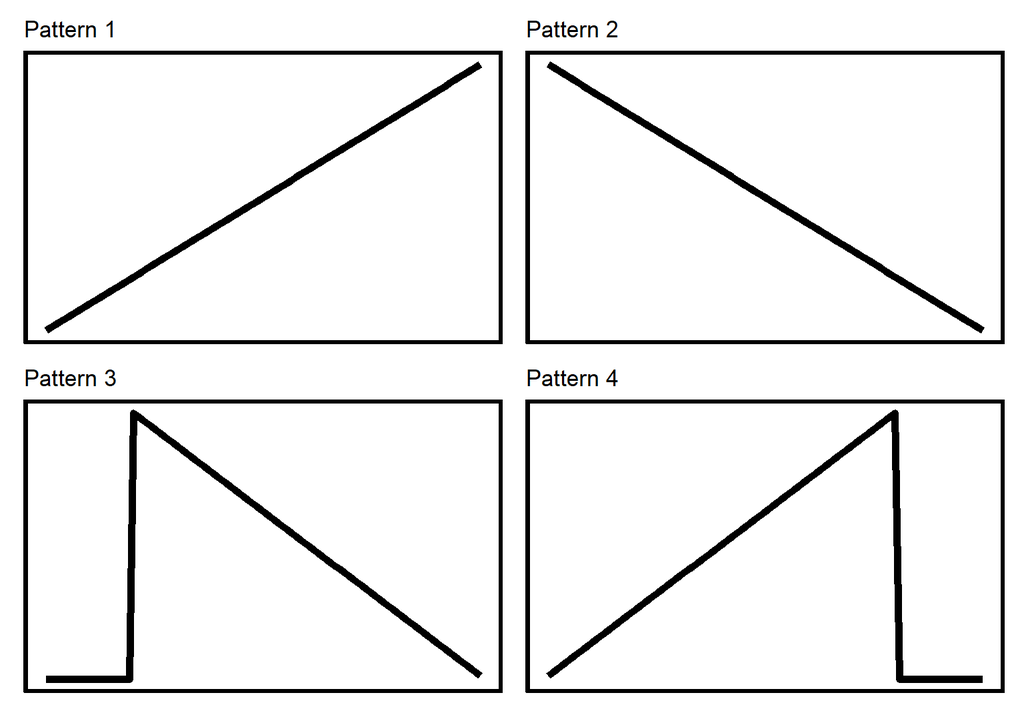

- **Prophage-like:**

There are three patterns in the Prophage-like class. The block pattern is representative of reads from inegtrated genetic elements, like prophage or phage-inducible chromosomal islands (PICIs), mapping back to their respective integration sites in the host bacterium’s chromosome. The block patterns are built based on the length of the contig being assessed. The top of the block starts at the contig’s maximum coverage value while the base starts at the contig’s minimum coverage value. The block width starts close to the length of the contig however this can be changed with the user-defined variable `maxblocksize`. While most prophage tend to be in the 30-60 kbp range, some are much larger. As a default, we do not set an upper-limit for the Prophage-like pattern because the upper-limit of prophage sizes is not known. The block heights are decreased followed by the block’s width to ensure a variety of block height/width combinations are tested. The block widths never get smaller than 10 kbp as a default as it can be difficult to distinguish between prophage-like elements and other mobile genetic elements, like transposons, in that size range. However, the minimum block width is a user-defined variable (`minblocksize`) and can be changed if smaller mobile genetic elements are of interest. The block heights are decreased followed by the block’s width to ensure that a variety of block height/width combinations are tested. Pattern 1 represents a prophage-like element that is entirely on the contig while patterns 2 and 3 represent a prophage-like element that trails off the right or left side of the contig, respectively. Each pattern variation is translated across the contig being assessed.

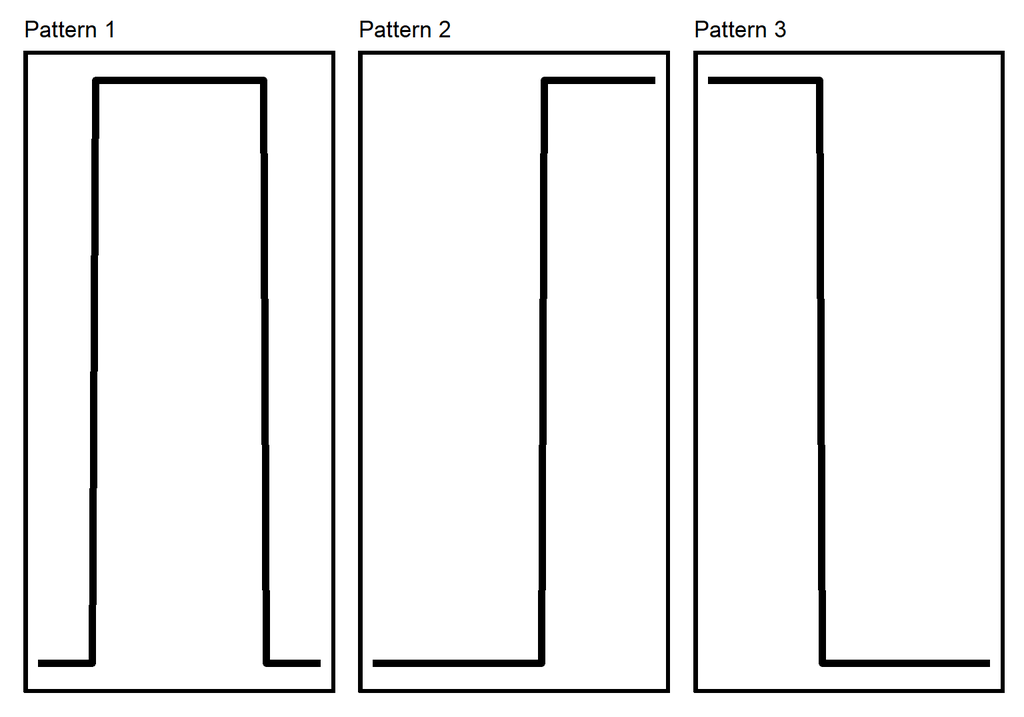

- **No pattern:**

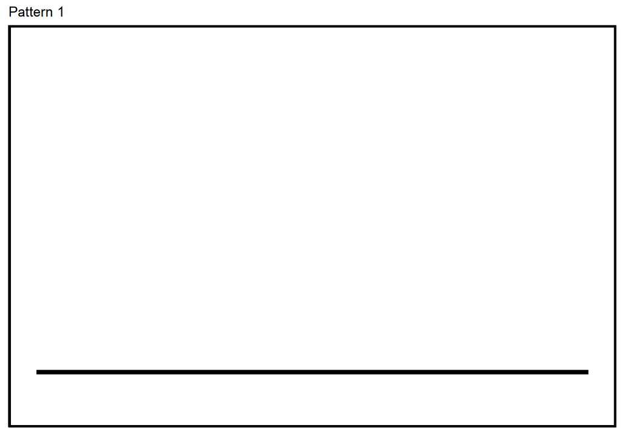

**3. Identifying highly active/abundant OR heterogenously present prophage-like elements:**

A prophage or prophage-like genetic element that is actively replicating or exists in high abundance will generate more reads than its respective host bacterium. This may create a region of elevated read coverage at the elements' genetic insertion sites that can be visualized in the whole-community fraction contigs. Conversely, if a prophage-like genetic element is only integrated into a portion of the host bacterial population, the read coverage at the insertion site will drop in comparison to the read coverage neighboring the insertion site. Since TrIdent locates prophage-like elements as part of its pattern-matching functionality, we can use these genetic 'coordinates' to see if the associated prophage-like region has elevated or decreased read coverage in the whole-community fraction. Contigs where the prophage-like:non-prophage-like region has a mean read coverage ratio of greater than 1.3 are labeled highly active/abundant whereas a mean read coverage ratio less than 0.5 are labeled as not homogenously integrated into the host population ('mixed'). If the non-prophage-like region is less than 20,000 bp, then the contig is labeled as ‘CBD’ (Can’t Be Determined) as its difficult to determine if the prophage-like region is truely elevated or depressed when there is so little non-prophage-like region to compare to.

**4. Identifying contigs with high VLP-fraction:whole-community read coverages:**

Contigs that are classified as have 'No pattern' via pattern-matching are assessed to see if they have high VLP-fraction:Whole-community median read coverage ratios. A contig with no pattern match that has an unusually high amount of bacterial DNA in the VLP-fraction may represent the ‘tail’ of a sloping pattern formed by a Sloping event, unknown transduction pathways or contamination from other sources e.g. very small, very dense cells that were co-purified with VLPs. As mentioned in the pattern-matching section for Sloping transduction events above, depending on which part of the sloping read coverage pattern is captured by a contig, the sloping can vary from being very steep to almost non-existent. Typically the ‘tails’ of sloping events have very little to no slope, but still represent transduction events. To differentiate contigs classified as having 'No pattern' that represent real transduction events and those that represent no transduction, we use the median read coverage ratio between the VLP-fraction and whole-community metagenome. The idea is that contigs with a high amount of VLP-fraction read coverage relative to the whole-community metagenome read coverage may represent real transfer events rather than just contaminating bacterial DNA. If the VLP-fraction has a median read coverage of greater than 50% of the median read coverage in the whole-community metagenome, then the contig is classified as having high VLP-fraction read coverage but no distinct read coverage pattern (HighCoverageNoPattern). It is up to the user to decide if they would like to include or exclude these classifications in their assessment. **NOTE: The HighCoverageNoPattern phenomenom is very much impacted by how many reads are sequenced for the whole-community versus the VLP fraction. For example, if you sequence a lot more reads for the VLP fraction as compared to the whole community the ratio may be less meaningful as it increases automatically with more reads sequenced for the VLP fraction. As such, one needs to be careful in the interpretation of these ratios.**

#### **`TrIdent_Classifier()` user parameters:**

- `VLP-pileup`
- `WC_pileup`
- `windowsize`
- `minblocksize`
- `maxblocksize`
- `mincontiglength`
- `SaveFilesTo`
- `cleanup`

`VLP-pileup` A dataframe containing contig names, coverages averaged over 100bp windows, and contig positions associated with mapping VLP-fraction reads to whole-community contigs

`WC_pileup` A dataframe containing contig names, coverages averaged over 100bp windows, and contig positions associated with mapping whole-community reads to whole-community contigs

`windowsize` TrIdent resizes the bins or ‘windows’ used by `pileup.sh` to improve processing time and reduce noise in the data. Resizing is done by averaging the read coverages across the specified windowsize. `TrIdent_Classifier()` resizes windows to 1000 bp as a default. Depending on the dataset, the user may want to select a different windowsize. Users can choose between windowsizes of 200, 500, 1000 or 2000 ONLY. We recommend increasing the `windowsize` to 2000 if processing speed is of importance or if data is noisy (i.e. VLP-fraction contaminated with external bacterial DNA). We recommend decreasing the `windowsize` if your data is very clean and/or small and you are interested in increasing the resolution of read coverage patterns for the initial classification of contigs. Note that decreasing the windowsize will increase TrIdent’s processing time! Increasing/decreasing the `windowsize` may alter the results of the `TrIdent_Classifier()` slightly. Prophage-like classifications tend to stay the same when `windowsize` is changed, but Sloping and HighCoverageNoPattern classifications may switch classes with each other. This is due to how averaging the read coverages affects the sloping pattern./p>

`minblocksize` The minimum size of prophage-like patterns. The default is 10,000bp.

`maxblocksize` The maximum size of prophage-like patterns. The default is undefined/NA (i.e. no max size).

Be aware that changing the `minblocksize` and `maxblocksize` will not necessarily remove contigs with prophage-like patterns smaller/larger than the defined parameters from the resulting classifications. Contigs with prophage-like patterns larger/smaller than the `maxblocksize` and `minblocksize` may still be classified, however, the classifications and associated pattern matches may be poor. For example, if a contig has a clear prophage-like pattern that’s ~50,000 bp but the user sets the `maxblocksize=40000`, TrIdent will likely still classify the contig as prophage-like as the maximum block-like pattern of 40,0000 bp will still achieve a lower pattern match score than any of the Sloping or 'No pattern' patterns.

`mincontiglength` The minimum contig length used processed for pattern-matching. Contigs shorter than the `mincontiglength` will be filtered out prior to pattern-matching. The default is 30,000 bp

`SaveFilesTo` A file path in which TrIdent saves outputs to. This is useful if using TrIdent in a command-line environment. Default is that files are NOT saved to an output folder.

`cleanup` If TRUE, TrIdent will clean and re-format the input pileup files to ensure they are in the correct format for pattern-matching. If FALSE, users are responsible for putting their input files into the correct format (specified above). TRUE by default.

#### Default:

To run `TrIdent_Classifier()` in default-mode, run the following:

```r
TrIdent_results <- TrIdent_Classifier(VLP_pileup=VLPFraction_sampledata, WC_pileup=WholeCommunity_sampledata)
## Starting pattern-matching...
## A quarter of the way done with pattern_matching
## Half of the way done with pattern_matching
## Almost done with pattern_matching!
## Identifying potential transducing events
## Determining sizes (bp) of potential transduction events
## Identifying highly active/abundant or heterogenously integrated prophage-like elements
## Finalizing output
## Execuion time: 23.9757790565491
## 1 contigs were filtered out based on low read coverage
## 0 contigs were filtered out based on length
##
##             Sloping   HighCoverageNoPattern  InsufficientCoverage  Prophage-like
##                2                2                      1                  4
## 2 of the prophage-like classifications are highly active or abundant
## 1 of the prophage-like classifications are 'mixed', i.e. heterogenously integrated into their bacterial host population
##
```

`TrIdent_Classifier()` outputs a histogram containing the distribution of normalized pattern-match scores for your dataset. The normalized pattern-match score is the pattern-match score for a specific classification divided by the contig's average read coverage. This normlaized match score is an indicator of a pattern-match's quality i.e. how well the TrIdent pattern fits the associated contig's read coverage profile. Smaller match-scores, and normalized match-scores, indicate better pattern matches. The histogram can be used to filter the resulting TrIdent classifications by quality of pattern matches. A suggested filtering threshold is marked on the plot with a vertical line, however, the suggested threshold tends to be stringent and quality pattern-matches may be filtered out if the upper threshold boundary is not explored. For this reason, we encourage users to initially test a filtering value slightly greater than the suggested threshold.

For the test dataset, the resulting histogram looks like this:

[figure not shown]

However, for a 'real' dataset, the histogram looks like more of a normal distribution:

[figure not shown]

#### Obtain results of main classifier:

The output of `TrIdent_Classifier()` is a list containing five objects:

1. Full_summary_table: A summary table containing the classification information for all contigs that were not filtered out.
2. Cleaned_summary_table: A cleaned summary table containing the classification information for all contigs classified as either Prophage-like, Sloping, or HighCoverageNoPattern (i.e. ‘InsufficientCoverage’ classifications removed)
3. PatternMatchInfo: A list of pattern-match info that is used by other functions in TrIdent.
4. FilteredOutContig_table: A table of contigs that were filtered out and the reason why (either low read coverage or too short(<30kbp)).
5. Windowsize: The windowsize used.

Save the desired list-item to a new variable using its associated name:

```r
TrIdent_summary_table <- TrIdent_results$Full_summary_table
```

The TrIdent_Classifier output summary table

[output not shown]

```r
filteredout_contigs <- TrIdent_results$FilteredOutContig_table
```

The TrIdent_Classifier filtered-out contig summary table

| filteredout_contigs | reason |
| --- | --- |
| NODE_4 | Low VLP-fraction read cov |

### `Plot_TrIdentPatternMatches()`:

`Plot_TrIdentPatternMatches()` will output a list of read coverage plots of all contigs predicted as either Sloping, Prophage-like, or HighCoverageNoPattern and their respective pattern matches.

#### **`Plot_TrIdentPatternMatches()` user parameters:**

- `VLP-pileup`
- `WC_pileup`
- `transductionclassifications`
- `MatchScoreFilter`
- `SaveFilesTo`
- `cleanup`

`VLP-pileup`A dataframe containing contig names, coverages averaged over 100bp windows, and contig positions associated with mapping VLP-fraction reads to whole-community contigs

`WC_pileup`A dataframe containing contig names, coverages averaged over 100bp windows, and contig positions associated with mapping whole-community-fraction reads to whole-community contigs

`transductionclassifications`

The complete output from `TrIdent_Classifier()`

`MatchScoreFilter` Used to filter the `TrIdent_Classifier()` classifications by the quality of their respective pattern-matches. Choose the filtering theshold using the histogram of normalize pattern-match scores output with `TrIdent_Classifier()`. There is no filter set by default.

`SaveFilesTo` A file path in which TrIdent saves outputs to. Each plot is saved as an indiviudal png file named by the associated contig reference name. This is useful if using TrIdent in a command-line environment. Default is that files are NOT saved to an output folder.

`cleanup`If TRUE, TrIdent will clean and re-format the input pileup files to ensure they are in the correct format for pattern-matching. If FALSE, users are responsible for putting their input files into the correct format (specified above). TRUE by default.

```r
TrIdent_patternmatches <- Plot_TrIdentPatternMatches(VLP_pileup=VLPFraction_sampledata, WC_pileup=WholeCommunity_sampledata, transductionclassifications=TrIdent_results)
```

View either all plots at once or one plot at a time. All of the output plots can be saved as individual `ggplot` objects for further manipulation by the user. Each plot is named by its respective contig accession. View all plots:

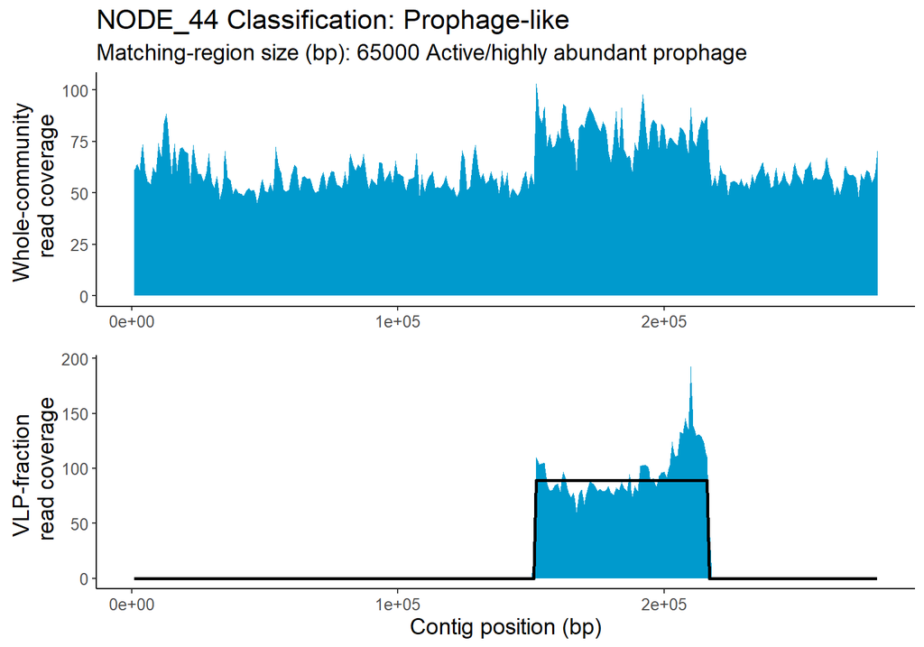

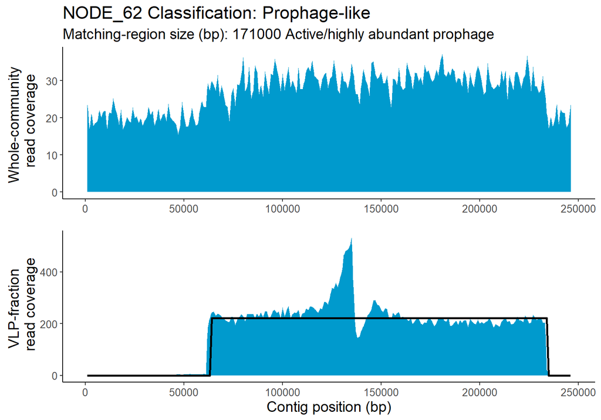

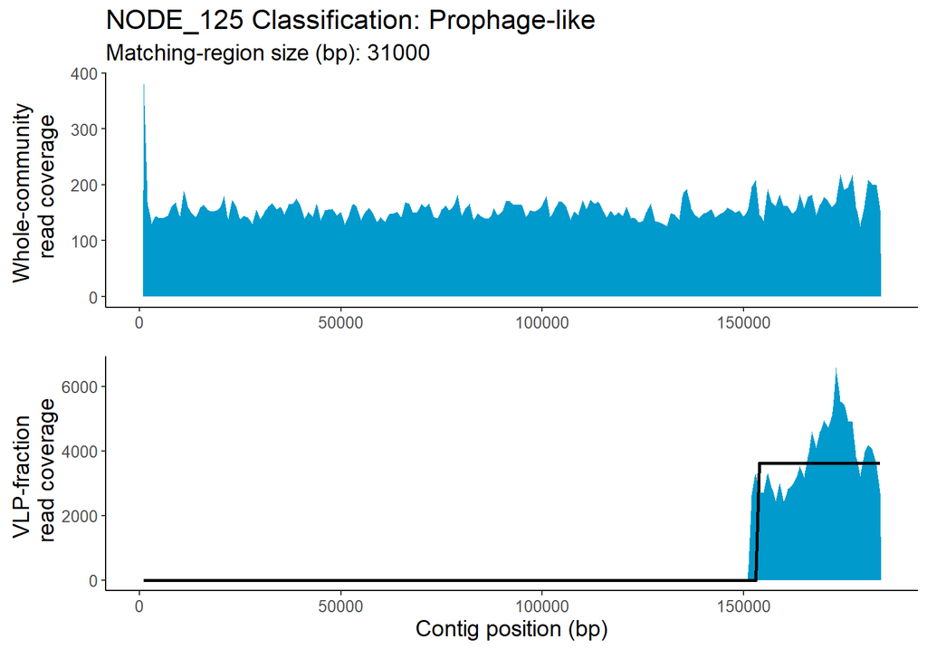

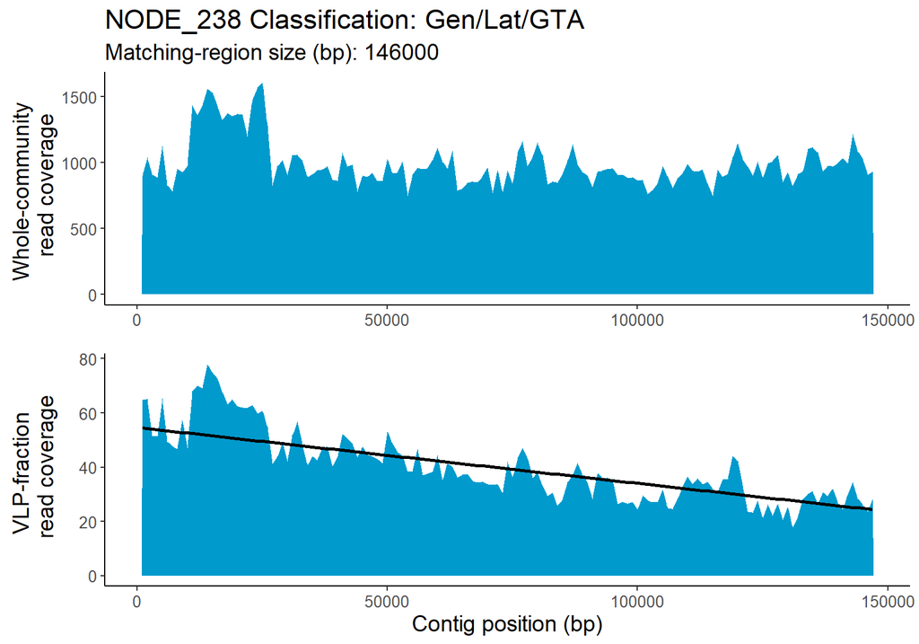

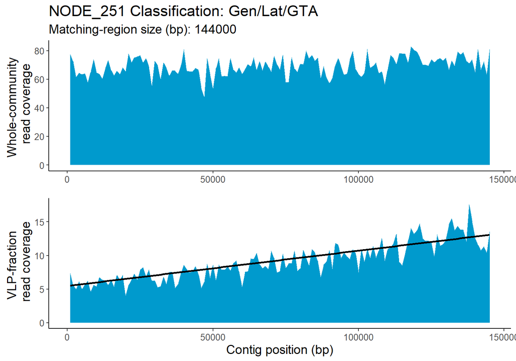

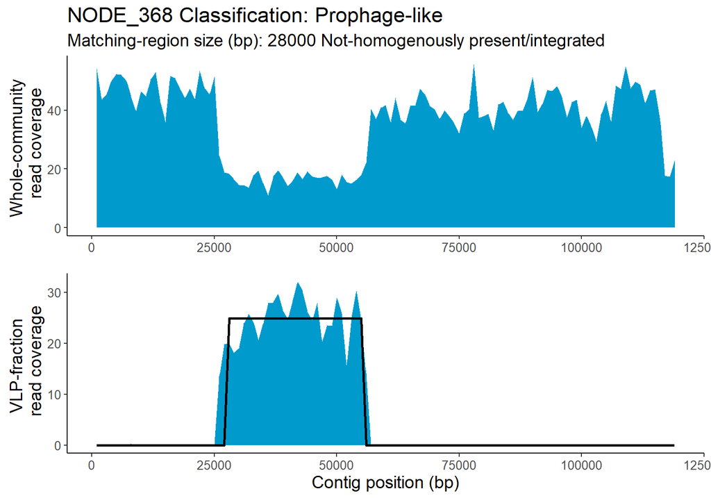

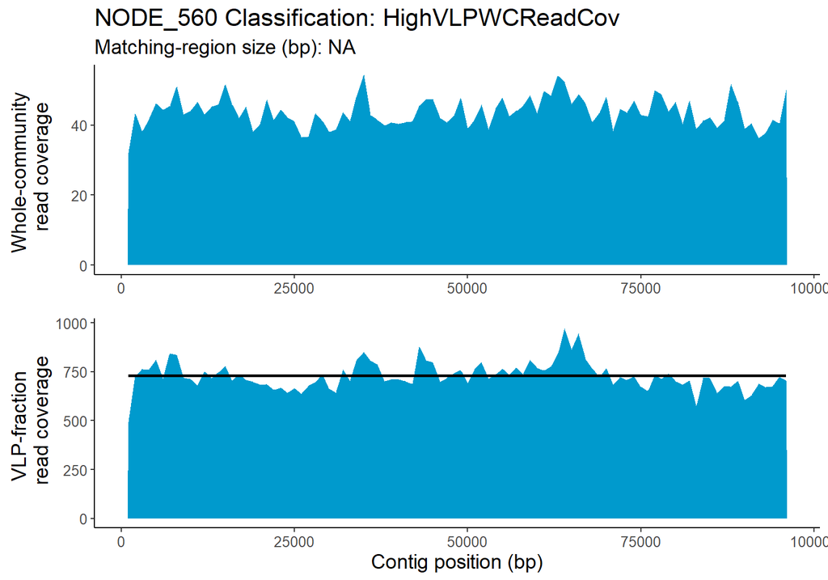

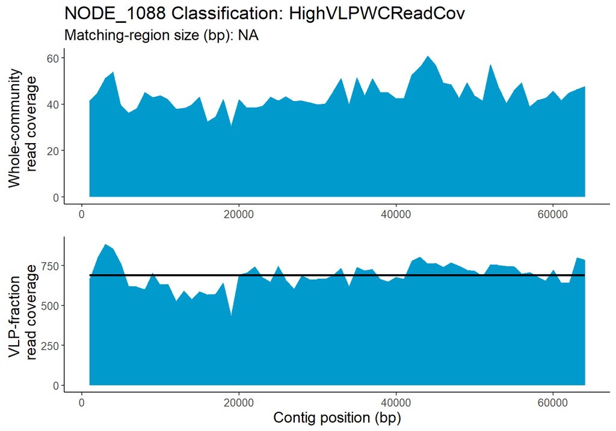

```r
TrIdent_patternmatches
```